# Raf test 3

Raffaello Raffin

5/20/2020

## Modeling at level_0 with ARIMA

In the Exploratory Data Analysis, we could see that our data had different seasonality. The weekly seasonality was particularly marked. So we decided to create a time series with a frequency of 7 days.

In the next section, we will try to fit an Arima model in different ways on the top level (TX1).

### Auto.arima without transformation

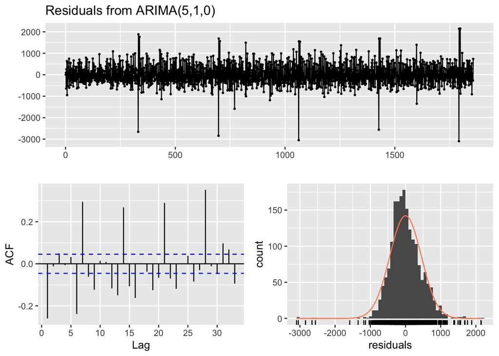

```
##
##  Ljung-Box test
##
## data:  Residuals from ARIMA(5,1,0)
## Q* = 437.2, df = 5, p-value < 2.2e-16
##
## Model df: 5.   Total lags used: 10
```

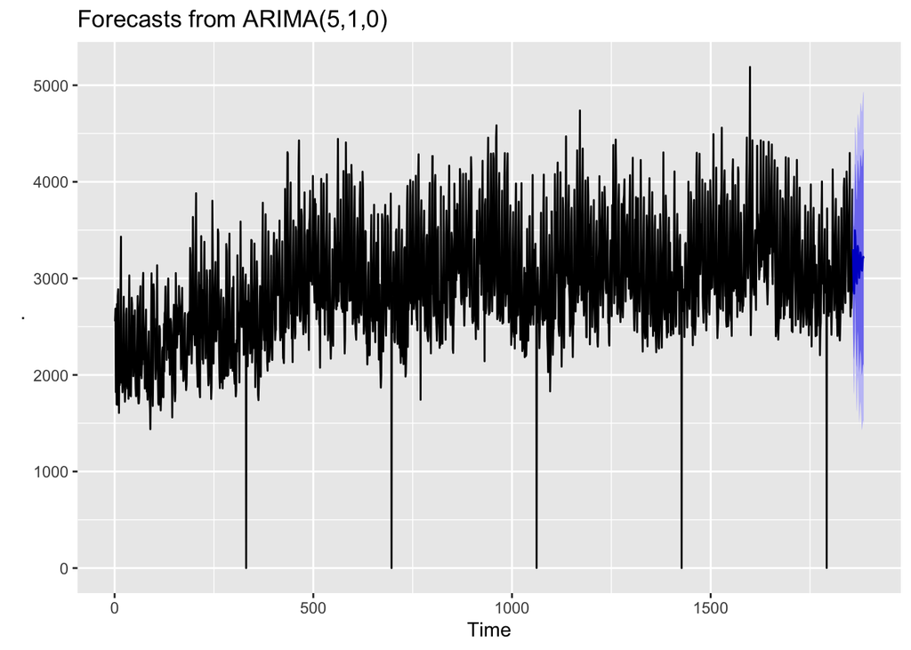

By looking at the residuals, we see that our model does not capture all the information contained in our data. We will, therefore, carry out two new tests by performing transformations ourselves before applying the auto.arima function.

### Auto.arima with transformation

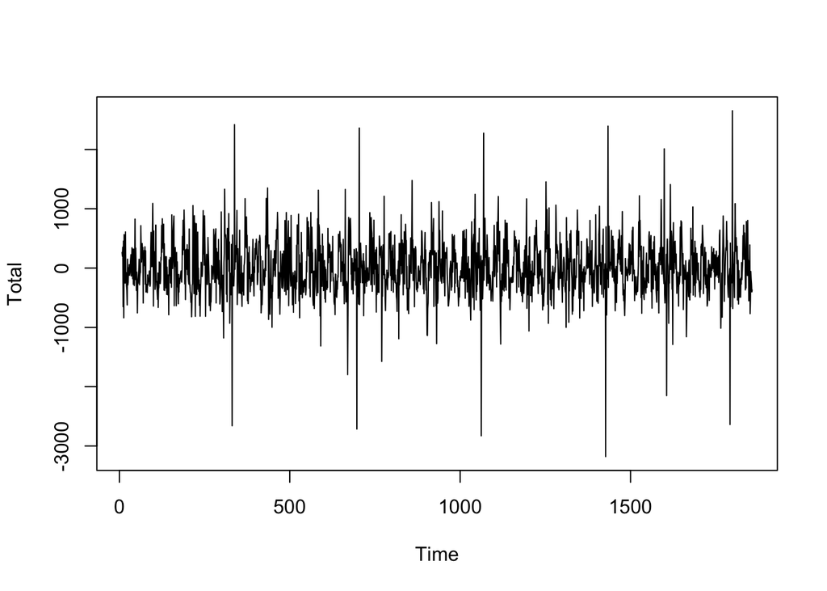

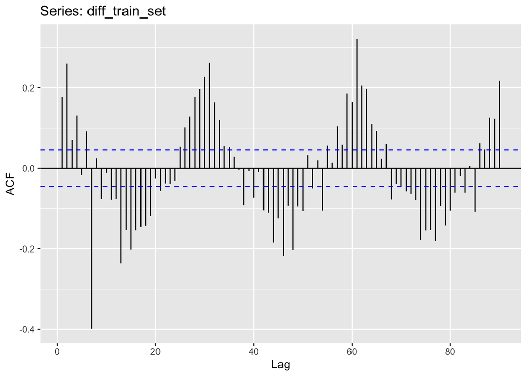

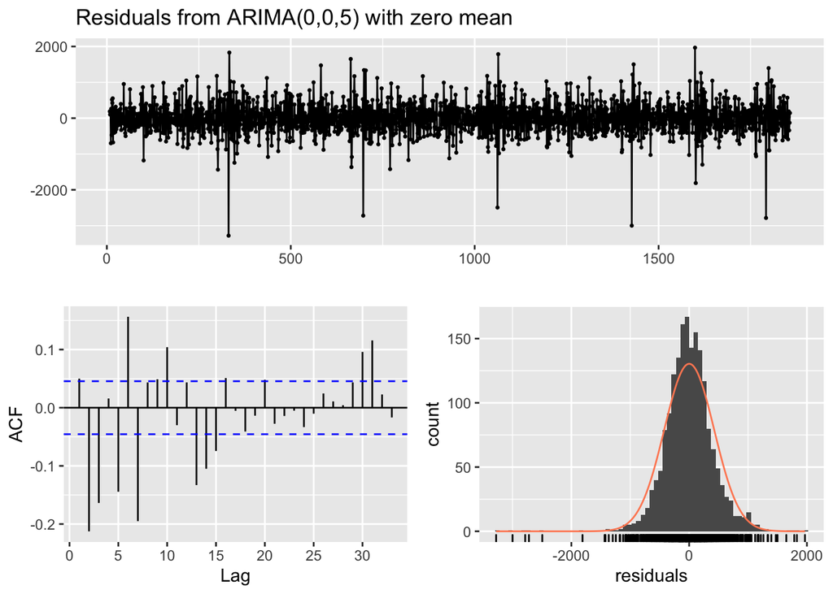

```
##
##  Ljung-Box test
##
## data:  Residuals from ARIMA(0,0,5) with zero mean
## Q* = 321.44, df = 5, p-value < 2.2e-16
##
## Model df: 5.   Total lags used: 10
```

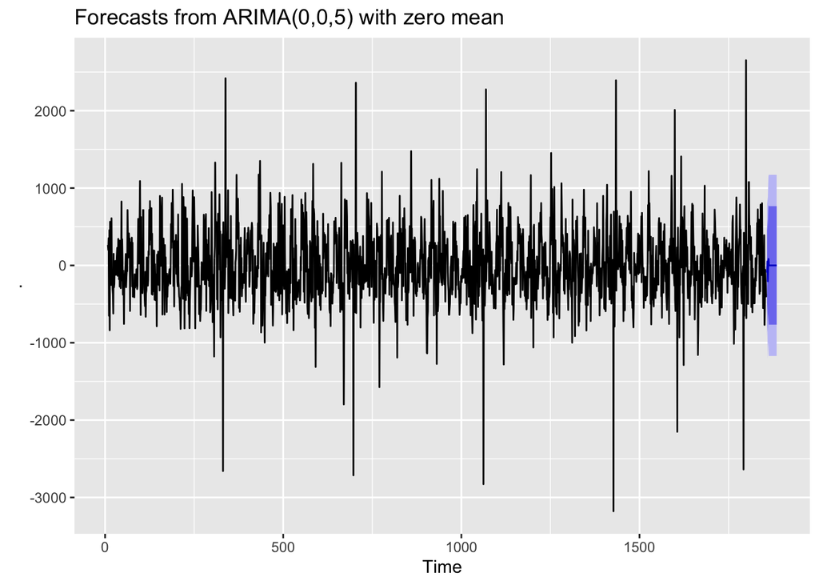

The ACF seems better but the Ljung-Box test still tells us that the residues of our model do not come from a white noise.

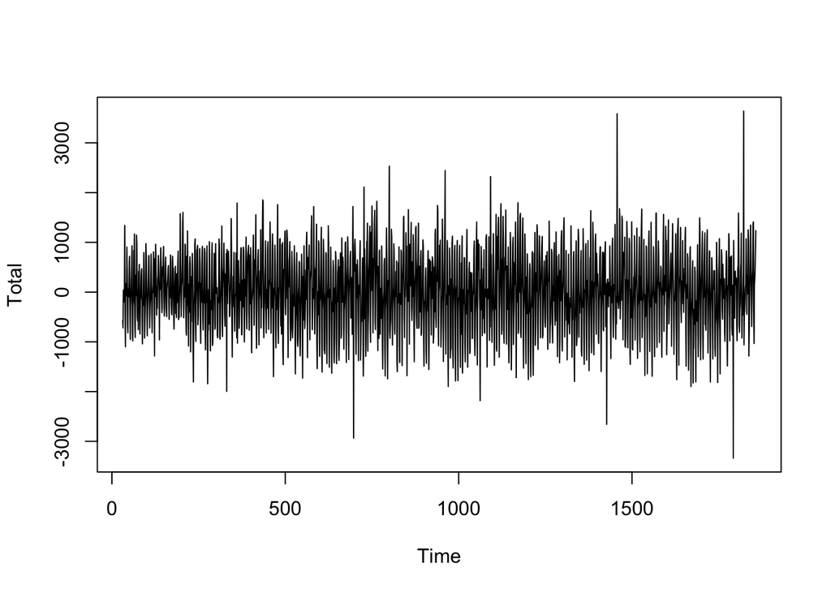

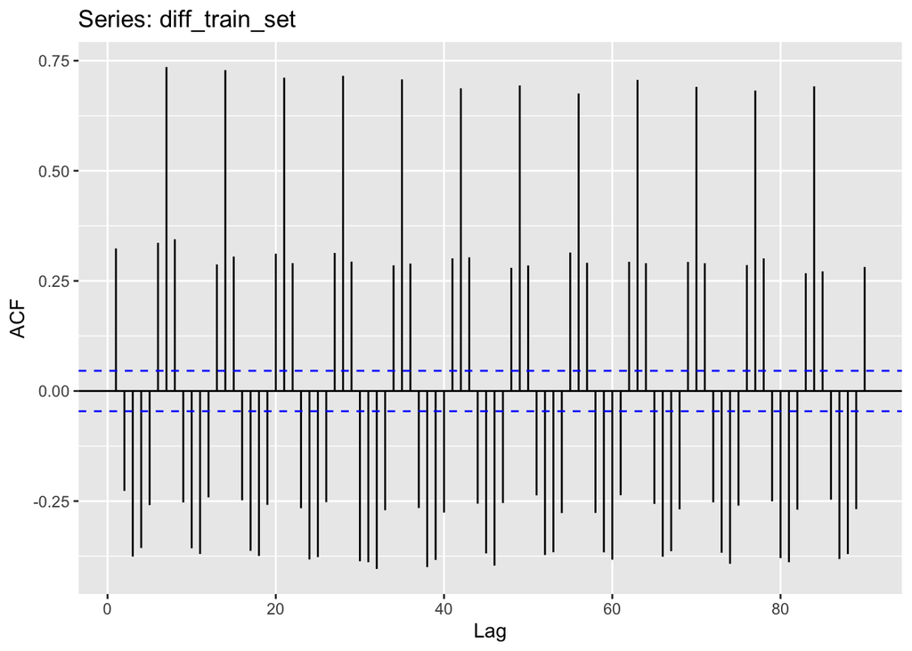

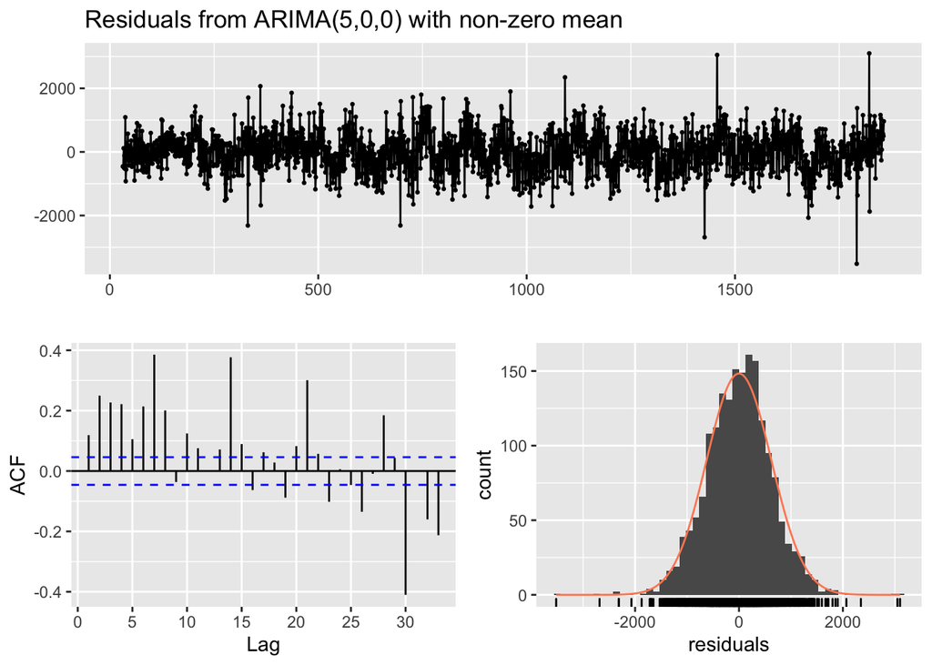

```
##
##  Ljung-Box test
##
## data:  Residuals from ARIMA(5,0,0) with non-zero mean
## Q* = 806.84, df = 4, p-value < 2.2e-16
##
## Model df: 6.   Total lags used: 10
```

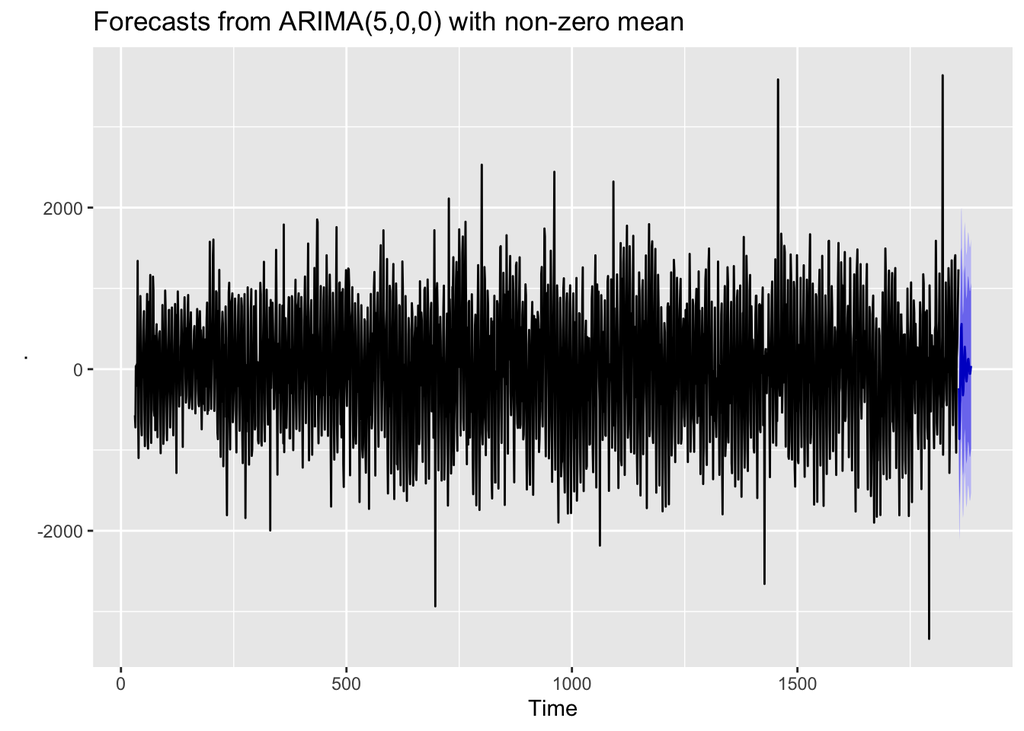

During this second test, we first apply a differentiation with a 30-day lag.

the ACF of our transformed data seems still not satisfactory.

Once again, the residuals of our model follow a normal law centered around zero but these always contain information not taken into account by the model.

Same conclusion when looking at the result of the Ljung-Box test.